# 23110238_ML_Pre_Requisite_Test

```python
import numpy as np
import matplotlib.pyplot as plt
```

**Question-1: How many multiplications and additions do you need to perform a matrix multiplication between a (n, k) and (k, m) matrix? Explain.**

Answer: n x m x k multiplications & n x m x (k-1) additions

Explaination: Our Resulting Matrix will be (n,m), therefore having n*m elements. For each row x column, we need to perform k multiplications and k-1 additions. This operation will be done to get each element of the resultant matrix, therefore, there would be n x m x k multiplications and n x m x (k-1) additions.

**Question-2: Write Python code to multiply the above two matrices. Solve using list of lists and then use numpy. Compare the timing of both solutions. Which one is faster? Why?**

```python
import time

x_list = [[1,2,3],[4,5,6],[7,8,9], [10,11,12]]
x_numpy = np.array(x_list)

y_list = [[2,3,4], [5,6,7], [8,9,10]]
y_numpy = np.array(y_list)

# Multiplying using numpy
t1_np = time.time()
multiplication_np = np.matmul(x_numpy, y_numpy)
t2_np = time.time()
print('Multiplying using numpy')
print(multiplication_np)
print('Time taken: ', t2_np-t1_np,end='\n\n')

# Multiplying manually
t1_manual = time.time()
def manual_mul(x, y):
  l2 = []
  for i in range(len(x)):
    l1 = []
    for k in range(len(y[0])):
      value = 0
      for j in range(len(x[0])):
        value += x[i][j]*y[j][k]
      l1.append(value)
    l2.append(l1)
  return l2
multiplication_manual = manual_mul(x_list, y_list)
t2_manual = time.time()
print('Multiplying manually')
print(multiplication_manual)
print('Time taken: ', t2_manual-t1_manual)

#Multiplying by numpy is way faster because it is written in low level languages like C and also uses optimized libraries like BLAS (Basic Linear Algebra Subprograms) and LAPACK (Linear Algebra Package).
```

```
Multiplying using numpy
[[ 36  42  48]
 [ 81  96 111]
 [126 150 174]
 [171 204 237]]
Time taken:  0.00016307830810546875

Multiplying manually
[[36, 42, 48], [81, 96, 111], [126, 150, 174], [171, 204, 237]]
Time taken:  0.0005786418914794922
```

**Question-3: Finding the highest element in a list requires one pass of the array. Finding the second highest element requires 2 passes of the the array. Using this method, what is the time complexity of finding the median of the array? Can you suggest a better method? Can you implement both these methods in Python and compare against numpy.median routine in terms of time?**

Answer:

For an array of length n, time complexity would be $n^2$

```python
def max_list(l):
  max_i = 0
  n = len(l)
  for i in range(n):
    if l[i] > l[max_i]:
      max_i = i
  return max_i

l = [7,8,9,4,5,6,1,2,3,13]
l2 = l
if len(l)%2 != 0:
  for i in range(len(l)//2):
    max_i = max_list(l2)
    l2.pop(max_i)
  median = l[max_list(l2)]

else:
  for i in range(len(l)//2-1):
    max_i = max_list(l2)
    l2.pop(max_i)
  median1 = l[max_list(l2)]
  l2.pop(max_list(l2))
  median2 = l[max_list(l2)]
  median = (median1+median2)/2
print('Median: ', median)
```

```
Median:  5.5
```

```python
def max_list(l, s=0, e='none'):
  e = e if e!='none' else len(l)
  n = e-s
  max_i = s
  if n==1:
    return s
  else:
    max1 = max_list(l,s,(s+e)//2)
    max2 = max_list(l, (s+e)//2, e)
    if l[max1] > l[max2]:
      return max1
    else:
      return max2

l = [7,8,9,4,5,6,1,2,3,13]
l2 = l
if len(l)%2 != 0:
  for i in range(len(l)//2):
    max_i = max_list(l2)
    l2.pop(max_i)
  median = l[max_list(l2)]

else:
  for i in range(len(l)//2-1):
    max_i = max_list(l2)
    l2.pop(max_i)
  median1 = l[max_list(l2)]
  l2.pop(max_list(l2))
  median2 = l[max_list(l2)]
  median = (median1+median2)/2
print('Median: ', median)
```

```
Median:  5.5
```

**Question-4: What is the gradient of the following function with respect to x and y?**

**$x^2 y + y^3 \sin x$**

Solution:

$f = x^2y+y^3sinx$

Answer:

gradient w.r.t. x = **$2xy+y^3cosx$** (Partial derivative w.r.t. x)

gradient w.r.t. y = **$x^2+3y^2sinx$** (Partial derivative w.r.t. y)

**Question-5: Use JAX to confirm the gradient evaluated by your method matches the analytical solution corresponding to a few random values of x and y**

```python
import jax
import jax.numpy as jnp

def f(x, y):
    return x**2 * y + y**3 * jnp.sin(x)

grad_f = jax.grad(f, argnums=(0, 1))

x_values = jnp.array([1.0, 2.0, 3.0])
y_values = jnp.array([0.5, 1.5, 2.5])

for x, y in zip(x_values, y_values):
    grad = grad_f(x, y)
    analytical_grad = (2 * x * y + y**3 * jnp.cos(x), x**2 + 3 * y**2 * jnp.sin(x))
    print(f"x: {x}, y: {y}")
    print(f"JAX gradient: \nw.r.t. x: {grad[0]}, w.r.t. y: {grad[1]}")
    print(f"Analytical gradient: \nw.r.t. x: {analytical_grad[0]}, w.r.t. y: {analytical_grad[1]}")
    print()
```

```
x: 1.0, y: 0.5
JAX gradient:
w.r.t. x: 1.067537784576416, w.r.t. y: 1.631103277206421
Analytical gradient:
w.r.t. x: 1.067537784576416, w.r.t. y: 1.631103277206421

x: 2.0, y: 1.5
JAX gradient:
w.r.t. x: 4.595504283905029, w.r.t. y: 10.137757301330566
Analytical gradient:
w.r.t. x: 4.595504283905029, w.r.t. y: 10.137757301330566

x: 3.0, y: 2.5
JAX gradient:
w.r.t. x: -0.46863269805908203, w.r.t. y: 11.645999908447266
Analytical gradient:
w.r.t. x: -0.46863269805908203, w.r.t. y: 11.645999908447266
```

**Question-6: Use sympy to confirm that you obtain the same gradient analytically.**

```python
import sympy as sp

x, y = sp.symbols('x y')

f = x**2 * y + y**3 * sp.sin(x)

grad_f = [sp.diff(f, var) for var in (x, y)]

print("Gradient w.r.t. x:", grad_f[0])
print("Gradient w.r.t. y:", grad_f[1])
```

```
Gradient w.r.t. x: 2*x*y + y**3*cos(x)
Gradient w.r.t. y: x**2 + 3*y**2*sin(x)
```

**Question-7: Create a Python nested dictionary to represent hierarchical information. We want to store record of students and their marks. Something like:**

1. **2022**
   1. **Branch 1**
      1. **Roll Number: 1, Name: N, Marks:**
         - **Maths: 100**
         - **English: 70**
   2. **Branch 2**
2. **2023**
   1. **Branch 1**
   2. **Branch 2**
3. **2024**
   1. **Branch 1**
   2. **Branch 2**
4. **2025**
   1. **Branch 1**
   2. **Branch 2**

```python
dict_marks = {2022: {'Branch 1': {1: {'Roll Number':1, 'Name': 'N1', 'Marks': {'Mathematics':100, 'English':70}},
                             2: {'Roll Number':2, 'Name': 'N2', 'Marks': {'Mathematics':100, 'English':70}}},
                'Branch 2': {3: {'Roll Number':3, 'Name': 'N3', 'Marks': {'Mathematics':100, 'English':70}},
                             4: {'Roll Number':4, 'Name': 'N4', 'Marks': {'Mathematics':100, 'English':70}}},
                'Branch 3': {5: {'Roll Number':5, 'Name': 'N5', 'Marks': {'Mathematics':100, 'English':70}},},},
         2023: {'Branch 2': {6: {'Roll Number':6, 'Name': 'N6', 'Marks': {'Mathematics':100, 'English':70}},},
                'Branch 3': {7: {'Roll Number':7, 'Name': 'N7', 'Marks': {'Mathematics':100, 'English':70}},},},
         2024: {'Branch 1': {8: {'Roll Number':8, 'Name': 'N8', 'Marks': {'Mathematics':100, 'English':70}},},
                'Branch 2': {9: {'Roll Number':9, 'Name': 'N9', 'Marks': {'Mathematics':100, 'English':70}},},},
         2025: {'Branch 3': {10: {'Roll Number':10, 'Name': 'N10', 'Marks': {'Mathematics':100, 'English':70}},},}, }

dict_marks
```

```
{2022: {'Branch 1': {1: {'Roll Number': 1,
    'Name': 'N1',
    'Marks': {'Mathematics': 100, 'English': 70}},
   2: {'Roll Number': 2,
    'Name': 'N2',
    'Marks': {'Mathematics': 100, 'English': 70}}},
  'Branch 2': {3: {'Roll Number': 3,
    'Name': 'N3',
    'Marks': {'Mathematics': 100, 'English': 70}},
   4: {'Roll Number': 4,
    'Name': 'N4',
    'Marks': {'Mathematics': 100, 'English': 70}}},
  'Branch 3': {5: {'Roll Number': 5,
    'Name': 'N5',
    'Marks': {'Mathematics': 100, 'English': 70}}}},
 2023: {'Branch 2': {6: {'Roll Number': 6,
    'Name': 'N6',
    'Marks': {'Mathematics': 100, 'English': 70}}},
  'Branch 3': {7: {'Roll Number': 7,
    'Name': 'N7',
    'Marks': {'Mathematics': 100, 'English': 70}}}},
 2024: {'Branch 1': {8: {'Roll Number': 8,
    'Name': 'N8',
    'Marks': {'Mathematics': 100, 'English': 70}}},
  'Branch 2': {9: {'Roll Number': 9,
    'Name': 'N9',
    'Marks': {'Mathematics': 100, 'English': 70}}}},
 2025: {'Branch 3': {10: {'Roll Number': 10,
    'Name': 'N10',
    'Marks': {'Mathematics': 100, 'English': 70}}}}}
```

**Question-8: Store the same information using Python classes. We have an overall database which is a list of year objects. Each year contains a list of branches. Each branch contains a list of students. Each student has some properties like name, roll number and has marks in some subjects.**

```python
class Marks:
  def __init__(self, maths, english):
    self.maths = maths
    self.english = english
class Branch:
  def __init__(self, name, students_list):
    self.name = name
    self.students = students_list
class Student:
  def __init__(self, roll_number, name, marks):
    self.roll_number = roll_number
    self.name = name
    self.marks = marks
class Year:
  def __init__(self, year, branches_list):
    self.year = year
    self.branches = branches_list
class Database:
  def __init__(self, years_list):
    self.years = years_list
  def __str__(self):
    list_years = self.years
    str_years = ''
    for year in list_years:
      str_years += str(year.year) + ': \n'
      for branch in year.branches:
        str_years += '\t' + branch.name + ': \n'
        for student in branch.students:
          str_years += '\t\t' + 'Roll Number: ' + str(student.roll_number) + ', Name: ' + student.name + ', Marks: \n'
          str_years += '\t\t\t' + 'Mathematics: ' + str(student.marks.maths) + ', English: ' + str(student.marks.english) + '\n'


    return str_years

year_2022 = Year(2022, [Branch('Branch 1', [Student(1,'N1', Marks(100,70)),Student(2,'N2', Marks(100,70))]), Branch('Branch 2',[Student(3,'N3', Marks(100,70)),Student(4,'N4', Marks(100,70))]), Branch('Branch 3', [Student(5,'N2', Marks(100,70))])])
year_2023 = Year(2023, [Branch('Branch 2', [Student(6,'N6', Marks(100,70))]), Branch('Branch 3', [Student(7,'N7', Marks(100,70))])])
year_2024 = Year(2024, [Branch('Branch 1', [Student(8,'N8', Marks(100,70))]), Branch('Branch 2', [Student(9,'N9', Marks(100,70))])])
year_2025 = Year(2025, [Branch('Branch 3', [Student(10,'N10', Marks(100,70))])])

overall_database = Database([year_2022, year_2023, year_2024, year_2025])
print(overall_database)
```

```
2022:
	Branch 1:
		Roll Number: 1, Name: N1, Marks:
			Mathematics: 100, English: 70
		Roll Number: 2, Name: N2, Marks:
			Mathematics: 100, English: 70
	Branch 2:
		Roll Number: 3, Name: N3, Marks:
			Mathematics: 100, English: 70
		Roll Number: 4, Name: N4, Marks:
			Mathematics: 100, English: 70
	Branch 3:
		Roll Number: 5, Name: N2, Marks:
			Mathematics: 100, English: 70
2023:
	Branch 2:
		Roll Number: 6, Name: N6, Marks:
			Mathematics: 100, English: 70
	Branch 3:
		Roll Number: 7, Name: N7, Marks:
			Mathematics: 100, English: 70
2024:
	Branch 1:
		Roll Number: 8, Name: N8, Marks:
			Mathematics: 100, English: 70
	Branch 2:
		Roll Number: 9, Name: N9, Marks:
			Mathematics: 100, English: 70
2025:
	Branch 3:
		Roll Number: 10, Name: N10, Marks:
			Mathematics: 100, English: 70
```

**Question-9: Using matplotlib plot the following functions on the domain: x = 0.5 to 100.0 in steps of 0.5.**

1. **$y = x$**
2. **$y = x^2$**
3. **$y = x^3/100$**
4. **$y = sin(x)$**
5. **$y = sin(x)/x$**
6. **$y = log(x)$**
7. **$y = e^x$**

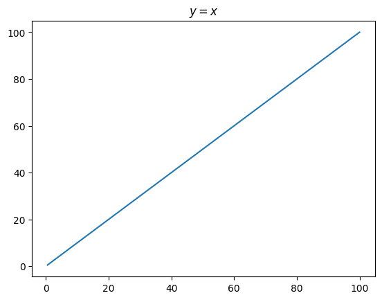

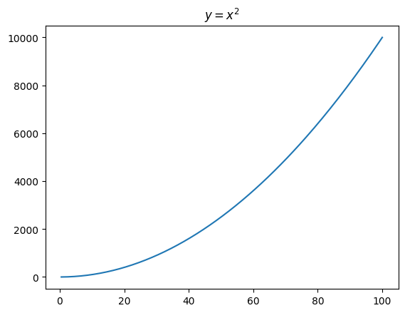

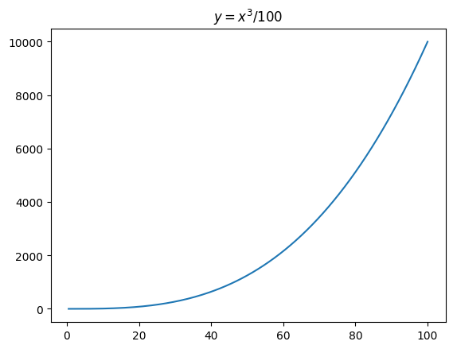

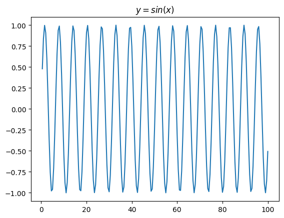

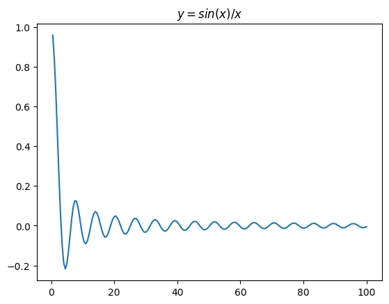

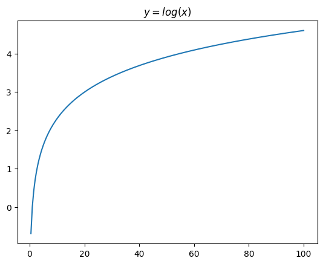

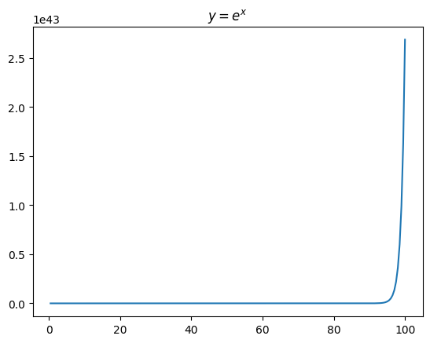

```python
# Answer:

x = np.arange(0.5,100.5,0.5)

def fxn1(x):
  return x
y1 = fxn1(x)
plt.plot(x, y1)
plt.title('$y = x$')
plt.show()

def fxn2(x):
  return x**2
y2 = fxn2(x)
plt.plot(x, y2)
plt.title('$y = x^2$')
plt.show()

def fxn3(x):
  return x**3/100
y3 = fxn3(x)
plt.plot(x, y3)
plt.title('$y = x^3/100$')
plt.show()

def fxn4(x):
  return np.sin(x)
y4 = fxn4(x)
plt.plot(x, y4)
plt.title('$y = sin(x)$')
plt.show()

def fxn5(x):
  return np.sin(x)/x
y5 = fxn5(x)
plt.plot(x, y5)
plt.title('$y = sin(x)/x$')
plt.show()

def fxn6(x):
  return np.log(x)
y6 = fxn6(x)
plt.plot(x, y6)
plt.title('$y = log(x)$')
plt.show()

def fxn7(x):
  return np.exp(x)
y7 = fxn7(x)
plt.plot(x, y7)
plt.title('$y = e^x$')
plt.show()
```

Question-10: Using numpy generate a matrix of size 20X5 containing random numbers drawn uniformly from the range of 1 to 2. Using Pandas create a dataframe out of this matrix. Name the columns of the dataframe as “a”, “b”, “c”, “d”, “e”. Find the column with the highest standard deviation. Find the row with the lowest mean.

```python
import pandas as pd

random_matrix = np.random.uniform(1,2,(20,5))
df = pd.DataFrame(random_matrix, columns=['a','b','c','d','e'])
print('Standard Deviation of all the columns: ', end="\n")
print(df.std(axis=0))
print('\n', end='')
print('Column with highest standard deviation:', df.columns[np.argmax(df.std(axis=0))], end='\n\n')
print('Standard Deviation of all the columns: ', end="\n")
print(df.std(axis=1))
print('\n', end='')
print('Row with highest standard deviation:')
df.loc[np.argmax(df.std(axis=1))]
```

```
Standard Deviation of all the columns:
a    0.311323
b    0.277702
c    0.311054
d    0.267584
e    0.268897
dtype: float64

Column with highest standard deviation: a

Standard Deviation of all the columns:
0     0.181455
1     0.156490
2     0.362975
3     0.304389
4     0.307982
5     0.299080
6     0.121744
7     0.335178
8     0.331792
9     0.303360
10    0.343313
11    0.126847
12    0.294176
13    0.301130
14    0.386416
15    0.316106
16    0.263769
17    0.168496
18    0.246458
19    0.310822
dtype: float64

Row with highest standard deviation:
```

|  | 14 |
| --- | --- |
| a | 1.094507 |
| b | 1.750192 |
| c | 1.912548 |
| d | 1.254931 |
| e | 1.921420 |

**dtype:** float64

Question-11: Add a new column to the dataframe called “f” which is the sum of the columns “a”, “b”, “c”, “d”, “e”. Create another column called “g”. The value in the column “g” should be “LT8” if the value in the column “f” is less than 8 and “GT8” otherwise. Find the number of rows in the dataframe where the value in the column “g” is “LT8”. Find the standard deviation of the column “f” for the rows where the value in the column “g” is “LT8” and “GT8” respectively.

```python
f = df.sum(axis=1)
df = pd.concat([df,f], axis=1)
df.rename(columns={0:'f'}, inplace=True)
df

def check_LT8(x):
  if (x<8):
    return 'LT8'
  else:
    return 'GT8'

df['g'] = df['f'].copy().apply(check_LT8)
df
```

|  | a | b | c | d | e | f | g |
| --- | --- | --- | --- | --- | --- | --- | --- |
| 0 | 1.746995 | 1.413527 | 1.493305 | 1.265760 | 1.591267 | 7.510853 | LT8 |
| 1 | 1.149847 | 1.388026 | 1.575640 | 1.279171 | 1.322376 | 6.715060 | LT8 |
| 2 | 1.906543 | 1.121181 | 1.030262 | 1.284274 | 1.063568 | 6.405828 | LT8 |
| 3 | 1.597136 | 1.845678 | 1.464660 | 1.021260 | 1.357135 | 7.285869 | LT8 |
| 4 | 1.039067 | 1.416681 | 1.748010 | 1.447969 | 1.015883 | 6.667611 | LT8 |
| 5 | 1.946696 | 1.291810 | 1.908729 | 1.739128 | 1.391659 | 8.278022 | GT8 |
| 6 | 1.496187 | 1.455253 | 1.304378 | 1.209305 | 1.279521 | 6.744643 | LT8 |
| 7 | 1.874589 | 1.079320 | 1.348422 | 1.685384 | 1.802671 | 7.790386 | LT8 |
| 8 | 1.597039 | 1.884579 | 1.054426 | 1.262991 | 1.230629 | 7.029665 | LT8 |
| 9 | 1.203834 | 1.592097 | 1.984091 | 1.824555 | 1.479348 | 8.083924 | GT8 |
| 10 | 1.434357 | 1.025557 | 1.633763 | 1.971344 | 1.577984 | 7.643005 | LT8 |
| 11 | 1.637810 | 1.767553 | 1.893127 | 1.952352 | 1.727823 | 8.978666 | GT8 |
| 12 | 1.181652 | 1.215622 | 1.673731 | 1.807989 | 1.700407 | 7.579400 | LT8 |
| 13 | 1.459597 | 1.870267 | 1.080918 | 1.447104 | 1.212955 | 7.070842 | LT8 |
| 14 | 1.094507 | 1.750192 | 1.912548 | 1.254931 | 1.921420 | 7.933598 | LT8 |
| 15 | 1.037567 | 1.876187 | 1.295959 | 1.401449 | 1.206624 | 6.817786 | LT8 |
| 16 | 1.911272 | 1.418297 | 1.881650 | 1.371665 | 1.823511 | 8.406395 | GT8 |
| 17 | 1.265082 | 1.302207 | 1.682044 | 1.489815 | 1.373329 | 7.112477 | LT8 |
| 18 | 1.183798 | 1.385109 | 1.794530 | 1.416559 | 1.199612 | 6.979608 | LT8 |
| 19 | 1.648778 | 1.648393 | 1.915665 | 1.302591 | 1.132679 | 7.648105 | LT8 |

Question-12: Write a small piece of code to explain broadcasting in numpy.

```python
a_np = np.array([[1,2,3],[4,5,6],[7,8,9]])
b_np = np.array([[1,2,3]])
a = [[1,2,3],[4,5,6],[7,8,9]]
b = [[1,2,3]]
print('Broadcasting by numpy')
print(a_np+b_np)

print('\nBroadcasting by manual code')
#How it works in Backend
def broadcasting_sum(a,b):
  ax = len(a[0])
  ay = len(a)
  bx = len(b[0])
  by = len(b)
  if ax == bx and ay == by:
    return a+b
  elif ax == bx and ay>by:
    b1 = b
    for i in range(ay-by):
      b = np.concatenate((b,b1), axis=0)
    return a+b

  elif ax == bx and ay<by:
    a1 = a
    for i in range(by-ay):
      a = np.concatenate((a,a1), axis=0)
    return a+b
  elif ax > bx and ay==by:
    b1 = b
    for i in range(ax-bx):
      b = np.concatenate((b,b1), axis=1)
    return a+b
  elif ax < bx and ay==by:
    a1 = a
    for i in range(bx-ax):
      a = np.concatenate((a,a1), axis=1)
    return a+b

print(broadcasting_sum(a,b))
```

```
Broadcasting by numpy
[[ 2  4  6]
 [ 5  7  9]
 [ 8 10 12]]

Broadcasting by manual code
[[ 2  4  6]
 [ 5  7  9]
 [ 8 10 12]]
```

Question-13: Write a function to compute the argmin of a numpy array. The function should take a numpy array as input and return the index of the minimum element. You can use the np.argmin function to verify your solution.

```python
x = np.array([[4,5,6],[7,8,9], [10,11,12],[2,1,3],])
def argmin(y):
  min_i = 0
  min_j = 0
  n_1 = len(y)
  n_2 = len(y[0])
  for i in range(n_1):
    for j in range(n_2):
      if y[i][j] < y[min_i][min_j]:
        min_i = i
        min_j = j
  return min_i, min_j

argmin(x)
```

```
(3, 1)
```